# Estimando la correlación entre variables

## Datos

Descarga de datos desde el sitio web https://hastie.su.domains/CASI/data.html

```r
data_url <- 'https://hastie.su.domains/CASI_files/DATA/student_score.txt'
df <- read.table(data_url, # archivo
                 sep = " ", # separador
                 header=TRUE # cabecera
                 )
```

## Exploración

Los datos recolectados corresponden a una muestra de 22 estudiantes tomados **al azar** desde una población de 88 estudiantes (Mardia et al., 1979). Las variables que se midieron corresponden a los resultados de las evaluaciones en las asignaturas mecánica (C), vectores (C), álgebra (O), análisis (O) y estadística (O); como se muestra a continuación. El puntaje es sobre 100 y hay dos tipos de examen: a libro abierto (O) y a libro cerrado (C)

```r
head(df)
```

```
##   mech vecs alg analy stat
## 1    7   51  43    17   22
## 2   44   69  53    53   53
## 3   49   41  61    49   64
## 4   59   70  68    62   56
## 5   34   42  50    47   29
## 6   46   40  47    29   17
```

Un resumen rápido nos dice que…

```r
summary(df)
```

```
##       mech            vecs            alg            analy
##  Min.   : 0.00   Min.   :30.00   Min.   :21.00   Min.   : 9.00
##  1st Qu.:31.25   1st Qu.:42.00   1st Qu.:47.00   1st Qu.:44.25
##  Median :42.00   Median :54.00   Median :50.50   Median :51.00
##  Mean   :36.82   Mean   :52.82   Mean   :50.45   Mean   :48.05
##  3rd Qu.:47.50   3rd Qu.:62.50   3rd Qu.:53.75   3rd Qu.:56.75
##  Max.   :63.00   Max.   :70.00   Max.   :68.00   Max.   :70.00
##       stat
##  Min.   :14.00
##  1st Qu.:29.25
##  Median :39.00
##  Mean   :40.82
##  3rd Qu.:53.75
##  Max.   :68.00
```

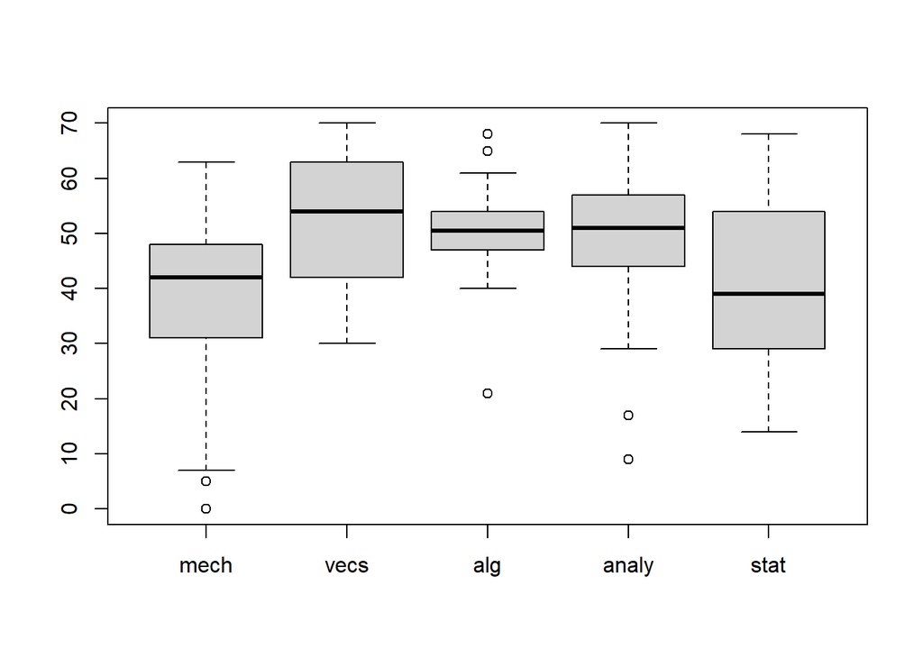

```r
boxplot(df)
```

En particular, tenemos las notas en las asignaturas de mécanica
$$M_1, M_2, \dots, M_{22} ~\sim ~M$$
y vectores
$$V_1, V_2, \dots, V_{22} ~\sim
~V$$

## Estimador de la correlación

El objetivo es determinar si hay redundancia al evaluar a los estudiantes sobre estas asignaturas (y si está redundancia vale no solo para la muestra sino para toda la población).

Para ello se considera el coeficiente de correlación muestral
$$\widehat{\theta}=
\frac{\sum_{i=1}^{22}\left(M_{i}-\bar{M}\right)\left(V_{i}-\bar{V}\right)
}{\left[\sum_{i=1}^{22}\left(M_{i}-\bar{M}\right)^{2}
\sum_{i=1}^{22}\left(V_{i}-\bar{V}\right)^{2}\right]^{1 / 2}},$$
donde $\theta$ es el coeficiente de correlación poblacional.

Si asumimos normalidad
$$(M,V)
~\sim~\mathcal{N}$$
entonces se puede obtener una fórmula para la densidad de $\widehat{\theta}$ (Fisher, 1915)
$$f_{\theta}(\hat{\theta})=\frac{(n-2)\left(1-\theta^{2}\right)^{(n-1) /
2}\left(1-\hat{\theta}^{2}\right)^{(n-4) / 2}}{\pi} \int_{0}^{\infty}
\frac{d w}{(\cosh w-\theta \hat{\theta})^{n-1}},$$
esta es una versión equivalente a la fórmula originalmente hallada por Fisher (Kotz, 1970).

**Distribución posteriori del estimador de la correlación**

Ahora armamos el esquema de estimación Bayesiana, para ello note que $\theta \in \Theta=[-1,1]$

Prior:

- Uniforme:
  $$\pi(\theta) =
  \frac{1}{2}, ~~\theta \in [-1,1]$$
- Jeffreys:
  $$\pi(\theta) =
  \frac{1}{1-\theta^2}, ~~\theta \in [-1,1]$$
- Triangular:
  $$\pi(\theta) =
  1-|\theta|, ~~\theta \in [-1,1]$$

Función de verosimilitud (1 observación):

$$\mathcal{L}(\theta) =
f_\theta(\widehat{\theta})$$

Posterior:

- Uniforme:
  $$\pi(\theta|\widehat{\theta}) ~\propto
  ~f_\theta(\widehat{\theta})$$
- Jeffreys:
  $$\pi(\theta|\widehat{\theta}) ~\propto ~f_\theta(\widehat{\theta})
  \frac{1}{1-\theta^2}$$
- Triangular:
  $$\pi(\theta|\widehat{\theta}) ~\propto ~f_\theta(\widehat{\theta})
  (1-|\theta|)$$

## Gráfico de la distribución del estimador de la correlación

Considerando los datos de la muestra

```r
x=df$mech
y=df$vecs
## estimador de máxima verosimilitud
theta.hat <- sum((x-mean(x))*(y-mean(y))) /(sum((x-mean(x))^2)*sum((y-mean(y))^2))^(1/2)
theta.hat
```

```
## [1] 0.4978075
```

se tiene que la constante antes de la integral, $C =\frac{(22-2)\left(1-\hat{\theta}^{2}\right)^{(22-4) / 2}}{\pi}$, vale 0.4907001, y por lo tanto las posteriori quedan

- Uniforme:
  $$\pi(\theta|\widehat{\theta}) ~\propto ~0.4907
  \left(1-\theta^{2}\right)^{21 / 2} \int_{0}^{\infty} \frac{d w}{(\cosh
  w- 0.4978\theta)^{21}}$$
- Jeffreys:
  $$\pi(\theta|\widehat{\theta}) ~\propto ~0.4907
  \left(1-\theta^{2}\right)^{19 / 2} \int_{0}^{\infty} \frac{d w}{(\cosh
  w- 0.4978\theta)^{21}}$$
- Triangular:
  $$\pi(\theta|\widehat{\theta}) ~\propto ~0.4907
  (1-|\theta|)\left(1-\theta^{2}\right)^{21 / 2} \int_{0}^{\infty} \frac{d
  w}{(\cosh w- 0.4978\theta)^{21}}$$

Graficando estas funciones se observa que…

```r
## y=0.5
f0 <- function(x){ 1/(cosh(x)-0.4978*0.5)^21 }
integrate(f0,0,Inf)
```

[output not shown]

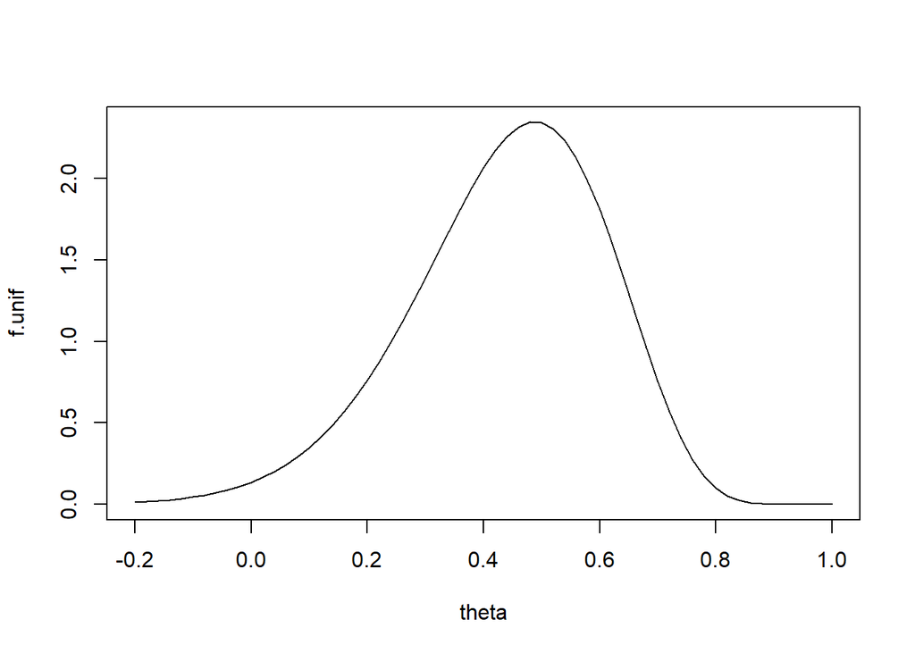

```r
theta <- seq(-0.2,1,0.02)
nn <- length(theta)
f.unif <- rep(0,nn)
for(ii in 1:nn){
    f0 <- function(x){ 1/(cosh(x)-0.4978*theta[ii])^21 }
    #print(f0(1))
    #print(integrate(f0,0,Inf)$value)
    #print(0.4907*((1-y*y)**(10.5)))
    f.unif[ii] <- 0.4907*((1-theta[ii]^2)**(10.5))*integrate(f0,0,Inf)$value
}
plot(theta,f.unif,type='l',col='black')
```

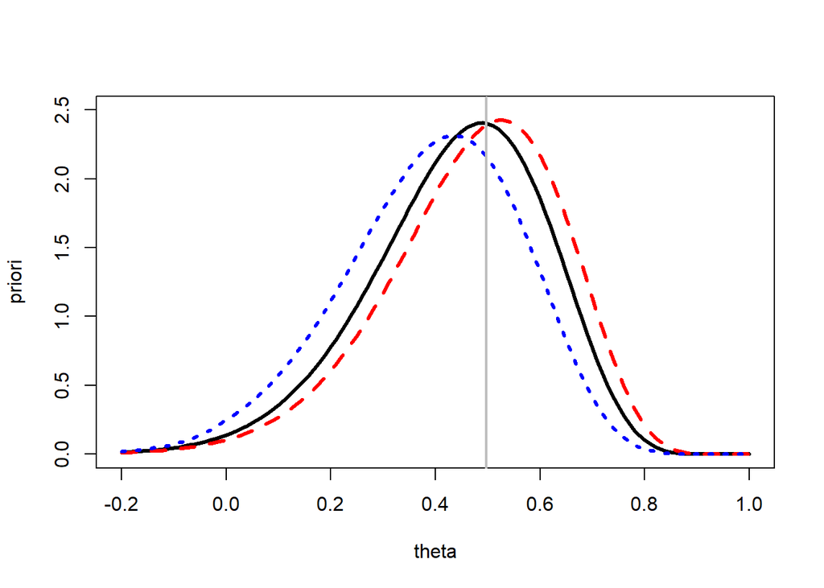

```r
theta <- seq(-0.2,1,0.01)
nn <- length(theta)
f.unif <- rep(0,nn)
f.jeff <- rep(0,nn)
f.tria <- rep(0,nn)
for(ii in 1:nn){
    f0 <- function(x){ 1/(cosh(x)-0.4978*theta[ii])^21 }
    #print(f0(1))
    #print(integrate(f0,0,Inf)$value)
    #print(0.4907*((1-y*y)**(10.5)))
    f.unif[ii] <- 0.4907*((1-theta[ii]^2)**(10.5))*integrate(f0,0,Inf)$value
    f.jeff[ii] <- 0.4907*((1-theta[ii]^2)**(9.5))*integrate(f0,0,Inf)$value
    f.tria[ii] <- 0.4907*(1-abs(theta[ii]))*((1-theta[ii]^2)**(10.5))*integrate(f0,0,Inf)$value
}
c.unif <- 0.01*sum(f.unif)
c.jeff <- 0.01*sum(f.jeff)
c.tria <- 0.01*sum(f.tria)
ff.unif <- f.unif/c.unif
ff.jeff <- f.jeff/c.jeff
ff.tria <- f.tria/c.tria
plot(theta,ff.unif,ylim=c(0,2.5),type='l',col='black',
     ylab='priori',lwd=3)
lines(theta,ff.jeff,type='l',col='red',lty=2,lwd=3)
lines(theta,ff.tria,type='l',col='blue',lty=3,lwd=3)
abline(v=theta.hat,col='gray',lwd=2)
```

Esto sugiere que efectivamente al momento de evaluar los conocimientos del curso de mecánica se evalúan también conocimientos de vectores desde que algunos temas de mecánica requieren el manejo de operaciones con vectores. Por lo tanto, la correlación es significativa y está explicada por la naturaleza de las asignaturas.

## Prueba de hipótesis

Veamos lo que nos dice una prueba de correlación

```r
cor.test(x,y)
```

```
##
##  Pearson's product-moment correlation
##
## data:  x and y
## t = 2.5669, df = 20, p-value = 0.01839
## alternative hypothesis: true correlation is not equal to 0
## 95 percent confidence interval:
##  0.09643983 0.75992335
## sample estimates:
##       cor
## 0.4978075
```

Con todo el conjunto de datos

```r
data_file <- 'student_score.txt'
df2 <- read.table(data_file, # archivo
                 sep = " ", # separador
                 header=TRUE # cabecera
                 )
cor.test(df2$vecs,df2$mech)
```

```
##
##  Pearson's product-moment correlation
##
## data:  df2$vecs and df2$mech
## t = 6.1616, df = 86, p-value = 2.246e-08
## alternative hypothesis: true correlation is not equal to 0
## 95 percent confidence interval:
##  0.3890571 0.6836124
## sample estimates:
##       cor
## 0.5534052
```

## Modelando mediante una regresión lineal

Finalmente, comparar con una prueba de hipótesis o un modelo de regresión lineal:

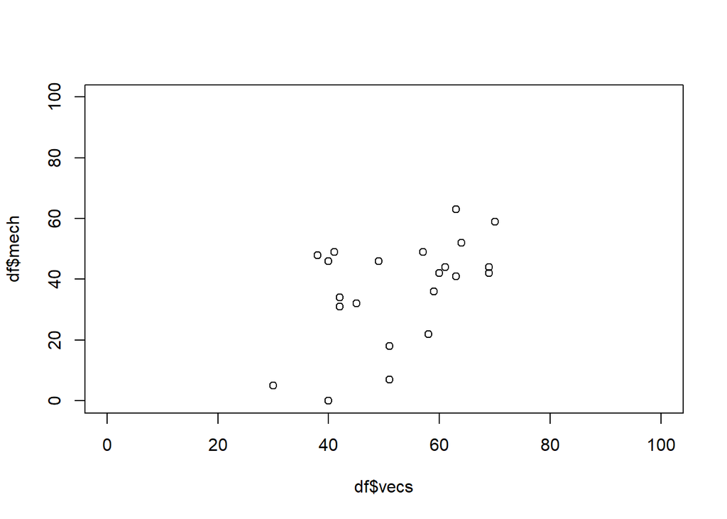

```r
plot(df$vecs,df$mech,xlim=c(0,100),ylim=c(0,100))
```

Ajuste del modelo lineal

```r
lm1 <- lm(mech ~ vecs,data=df)

print(lm1)
```

```
##
## Call:
## lm(formula = mech ~ vecs, data = df)
##
## Coefficients:
## (Intercept)         vecs
##      -1.369        0.723
```

```r
coef <- as.vector(lm1$coefficients)

summary(lm1) #plot(lm1)
```

```
##
## Call:
## lm(formula = mech ~ vecs, data = df)
##
## Residuals:
##     Min      1Q  Median      3Q     Max
## -28.504  -6.210   1.050   9.609  21.895
##
## Coefficients:
##             Estimate Std. Error t value Pr(>|t|)
## (Intercept)  -1.3694    15.2215  -0.090   0.9292
## vecs          0.7230     0.2817   2.567   0.0184 *
## ---
## Signif. codes:  0 '***' 0.001 '**' 0.01 '*' 0.05 '.' 0.1 ' ' 1
##
## Residual standard error: 15.11 on 20 degrees of freedom
## Multiple R-squared:  0.2478, Adjusted R-squared:  0.2102
## F-statistic: 6.589 on 1 and 20 DF,  p-value: 0.01839
```

Graficando

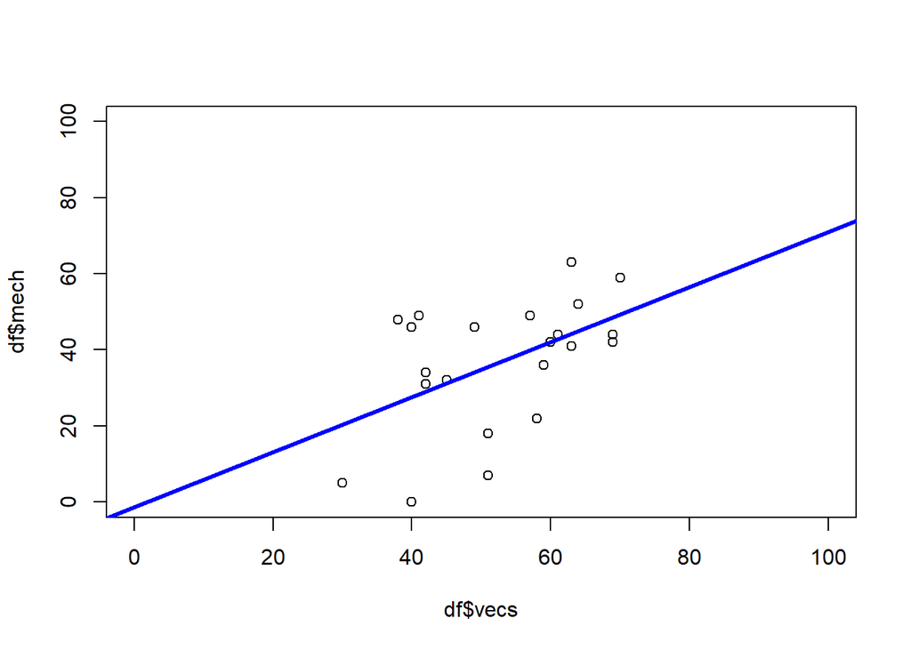

```r
plot(df$vecs,df$mech,xlim=c(0,100),ylim=c(0,100))
abline(lm1, col='blue', lwd=3)
```

Ajuste y residuos

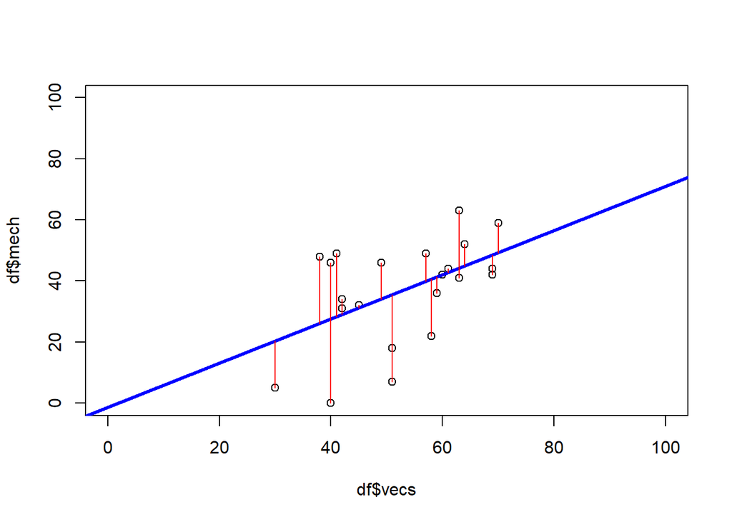

```r
plot(df$vecs,df$mech,xlim=c(0,100),ylim=c(0,100))
abline(lm1, col='blue', lwd=3)
segments(df$vecs,fitted(lm1), # punto ajustado
         df$vecs,df$mech, # punto real
         col='red')
```

Calculando los intervalos de confianza y los intervalos de predicción

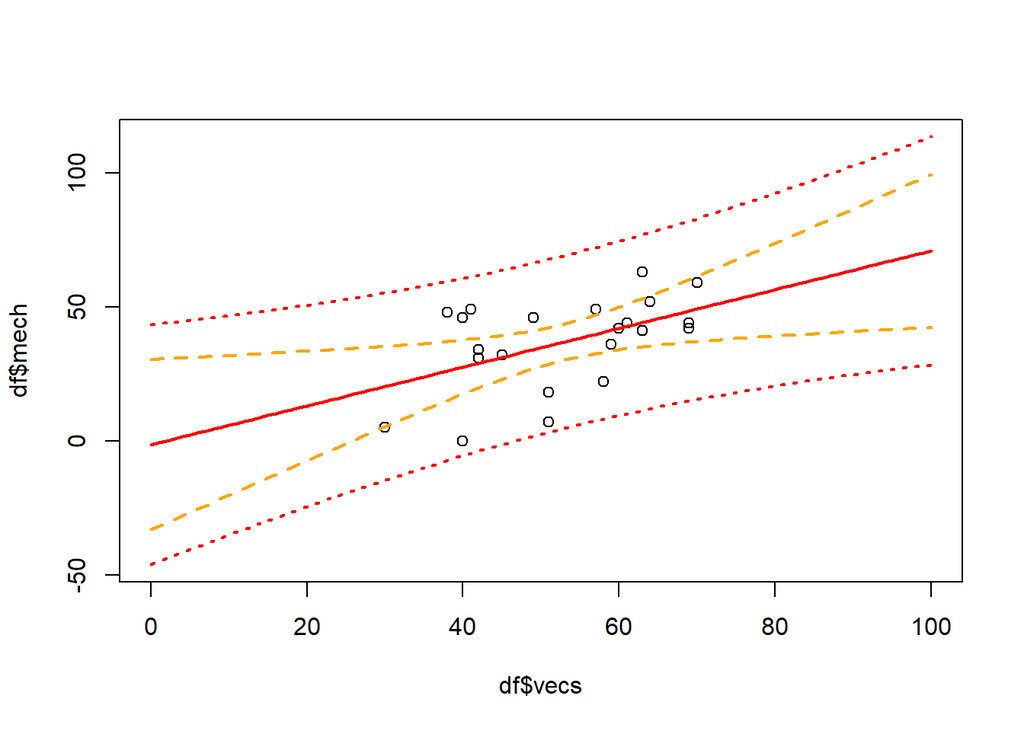

```r
pred.frame <- data.frame(vecs=0:100)
pred.vecs <- pred.frame$vecs

pred.mech <- predict(lm1, newdata=pred.frame)
pp <- predict(lm1, int="p", newdata=pred.frame)
pc <- predict(lm1, int="c", newdata=pred.frame)

?matlines

plot(df$vecs,df$mech, ylim=range(df$vecs, pp, na.rm=T), xlim=c(0,100))
#points(pred.vecs,pred.mech,col='orange',pch=2)
matlines(pred.vecs, pc, lty=c(1,2,2), col="orange", lwd=2)
matlines(pred.vecs, pp, lty=c(1,3,3), col="red", lwd=2)
```